# Weather Forecast Prediction

## By Adegun Ahmed Olamilekan

## Investigation Overview

Objective: The primary goal is to build a classification model that accurately predicts whether it will rain based on the input weather conditions.

Methodology: Dataset: The dataset file contains 6 columns with 2500 rows

Data Processing: Clean and transform the data for machine learning models

Exploratory Data Analysis (EDA): Use suitable charts to uncover trends, correlations in the data.

Model Evaluation: Use classification evaluation metrics to evaluate the model performance

Report: Comment on the overall insight

```python
# import Libraries

import pandas as pd

import numpy as np
import matplotlib.pyplot as plt
import seaborn as sns
from sklearn.model_selection import train_test_split
from sklearn.ensemble import RandomForestClassifier
from sklearn.preprocessing import LabelEncoder
from sklearn.metrics import classification_report, accuracy_score, confusion_matrix
```

```python
df = pd.read_csv("weather_forecast_data.csv")
df.head()
```

|  | Temperature | Humidity | Wind_Speed | Cloud_Cover | Pressure | Rain |
| --- | --- | --- | --- | --- | --- | --- |
| 0 | 23.720338 | 89.592641 | 7.335604 | 50.501694 | 1032.378759 | rain |
| 1 | 27.879734 | 46.489704 | 5.952484 | 4.990053 | 992.614190 | no rain |
| 2 | 25.069084 | 83.072843 | 1.371992 | 14.855784 | 1007.231620 | no rain |
| 3 | 23.622080 | 74.367758 | 7.050551 | 67.255282 | 982.632013 | rain |
| 4 | 20.591370 | 96.858822 | 4.643921 | 47.676444 | 980.825142 | no rain |

```python
# Check dataset Info
df.info()
```

```
<class 'pandas.core.frame.DataFrame'>
RangeIndex: 2500 entries, 0 to 2499
Data columns (total 6 columns):
 #   Column       Non-Null Count  Dtype
---  ------       --------------  -----
 0   Temperature  2500 non-null   float64
 1   Humidity     2500 non-null   float64
 2   Wind_Speed   2500 non-null   float64
 3   Cloud_Cover  2500 non-null   float64
 4   Pressure     2500 non-null   float64
 5   Rain         2500 non-null   object
dtypes: float64(5), object(1)
memory usage: 117.3+ KB
```

#### The columns in the dataset appear to be relatively compatible with their datatypes

```python
df.shape
```

```
(2500, 6)
```

```python
# Check for duplicates
df.duplicated().sum()
```

```
0
```

```python
# check summary Statistic
df.describe()
```

|  | Temperature | Humidity | Wind_Speed | Cloud_Cover | Pressure |
| --- | --- | --- | --- | --- | --- |
| count | 2500.000000 | 2500.000000 | 2500.000000 | 2500.000000 | 2500.000000 |
| mean | 22.581725 | 64.347094 | 9.906255 | 49.658104 | 1014.312336 |
| std | 7.326996 | 19.954739 | 5.780316 | 29.123104 | 20.196433 |
| min | 10.001842 | 30.005071 | 0.009819 | 0.015038 | 980.014486 |
| 25% | 16.359398 | 47.339815 | 4.761909 | 23.900016 | 996.938630 |
| 50% | 22.536448 | 63.920797 | 9.908572 | 49.488284 | 1013.433035 |
| 75% | 28.976476 | 81.561021 | 14.948408 | 75.324140 | 1031.735067 |
| max | 34.995214 | 99.997481 | 19.999132 | 99.997795 | 1049.985593 |

```python
# check for nan values

df.isna().sum()
```

```
Temperature    0
Humidity       0
Wind_Speed     0
Cloud_Cover    0
Pressure       0
Rain           0
dtype: int64
```

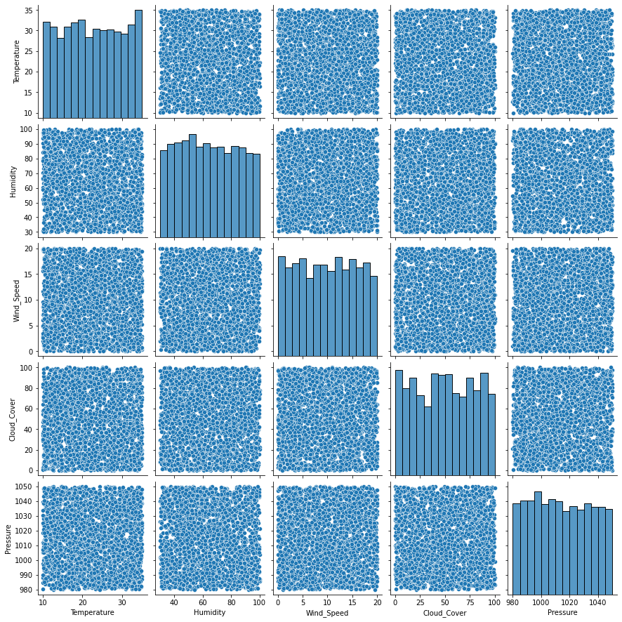

```python
# Check the comparison of all numerical variables

sns.pairplot(data=df);
```

#### The above shows the relationships between the attributes, the plot above shows that there is no significant relationship among the attribtes

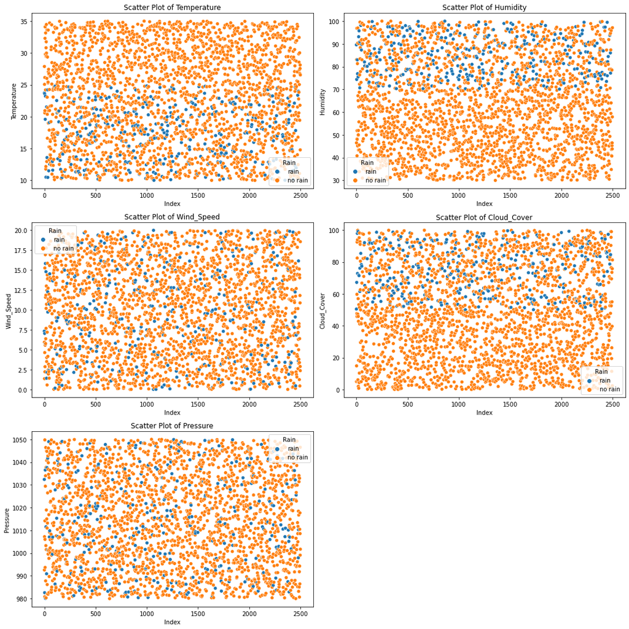

```python
import matplotlib.pyplot as plt
import seaborn as sns

plt.figure(figsize=(15, 15))

# Subplot 1: Distribution of Temperature
plt.subplot(3, 2, 1)
sns.scatterplot(x=df.index, y=df['Temperature'], hue=df['Rain'])
plt.title('Scatter Plot of Temperature')
plt.xlabel('Index')
plt.ylabel('Temperature')


# Subplot 2: Scatterplot of Humidity vs. Rain
plt.subplot(3, 2, 2)
sns.scatterplot(x=df.index, y=df['Humidity'], hue=df['Rain'])
plt.title('Scatter Plot of Humidity')
plt.xlabel('Index')
plt.ylabel('Humidity')


# Subplot 3: Scatterplot of Wind_Speed vs. Rain
plt.subplot(3, 2, 3)
sns.scatterplot(x=df.index, y=df['Wind_Speed'], hue=df['Rain'])
plt.title('Scatter Plot of Wind_Speed')
plt.xlabel('Index')
plt.ylabel('Wind_Speed')


# Subplot 4: Scatterplot of Cloud_Cover vs. Rain
plt.subplot(3, 2, 4)
sns.scatterplot(x=df.index, y=df['Cloud_Cover'], hue=df['Rain'])
plt.title('Scatter Plot of Cloud_Cover')
plt.xlabel('Index')
plt.ylabel('Cloud_Cover')

# Subplot 4: Scatterplot of Pressure vs. Rain
plt.subplot(3, 2, 5)
sns.scatterplot(x=df.index, y=df['Pressure'], hue=df['Rain'])
plt.title('Scatter Plot of Pressure')
plt.xlabel('Index')
plt.ylabel('Pressure')


# Adjust layout
plt.tight_layout()
plt.show()
```

The above graphs depict the relationships that exist between two attributs with regards to effect on the outcome on "rain" or "no rain".

It appears that there is more probability of an occurence of rainfall, where temperature seems to be lower, higher humidity and higher cloud cover.

```python
# Encoding the categorical column to numerical values

label_encoder = LabelEncoder()
df['Rain'] = label_encoder.fit_transform(df['Rain'])
```

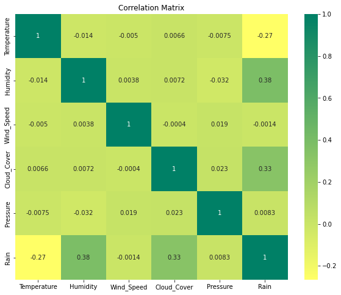

```python
# Generate a correlation matrix
correlation_matrix = df.corr()

plt.figure(figsize=(10, 8))
sns.heatmap(correlation_matrix, cmap='summer_r', annot =True)
plt.title("Correlation Matrix");
```

```python
## MODEL BUILDING
```

```python
# develop Train dataset and target variable

X = df.drop(columns= "Rain")
y = df.Rain
```

```python
# separate trainig set from test dataset

X_train, X_test, y_train, y_test = train_test_split(X,y, test_size=0.3, random_state=42)
```

```python
# Build Random Forest Classifier Mode

rf_model = RandomForestClassifier(n_estimators=500, max_depth=50)

rf_model.fit(X_train, y_train)
```

```
RandomForestClassifier(max_depth=50, n_estimators=500)
```

```python
#Predict model
pred_Rf = rf_model.predict(X_test)
```

```python
# Create a DataFrame for comparison
comparison_df = pd.DataFrame({
    'Actual': y_test,
    'Prediction': pred_Rf
})

# Print the DataFrame
print(comparison_df)
```

```
      Actual  Prediction
1447       0           0
1114       0           0
1064       1           0
2287       0           0
1537       0           0
...      ...         ...
427        0           0
105        1           1
2044       1           1
121        1           1
821        0           0

[750 rows x 2 columns]
```

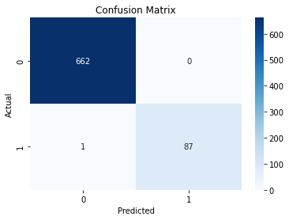

```python
# Generate the confusion matrix
cm = confusion_matrix(y_test, pred_Rf)

# Visualize the confusion matrix using seaborn heatmap
sns.heatmap(cm, annot=True, fmt='d', cmap='Blues')
plt.xlabel('Predicted')
plt.ylabel('Actual')
plt.title('Confusion Matrix')
plt.show()
```

```python
# # Generate the classification report
report = classification_report(y_test, pred_Rf)


val_accuracy = accuracy_score(y_test, pred_Rf)
# Print the report
print(f"Validation Accuracy:", val_accuracy)
print(report)
```

```
Validation Accuracy: 0.9986666666666667
              precision    recall  f1-score   support

           0       1.00      1.00      1.00       662
           1       1.00      0.99      0.99        88

    accuracy                           1.00       750
   macro avg       1.00      0.99      1.00       750
weighted avg       1.00      1.00      1.00       750
```

# Summary of Findings

### Accuracy

[output not shown]

### Precision

[output not shown]

### Recall

```
Class 0 (No Rain): 1.00
All true "No Rain" days are identified.

Class 1 (Rain): 0.99
99% of rainy days are correctly identified, with minimal misses. Missing even a small number of rainy days could matter depending on the use case, so continuous monitoring is advisable.
```

### F1 Score

```
Class 0 (1.00): Perfect balance between precision and recall.
Class 1 (0.99): High reliability for predicting rainy days despite the small minority class.
```